# tmep

### About Dataset

#### Analyzing Business Performance and Strategic Planning:

The online retail store has hired you as a consultant to analyse their data and provide insights to the CEO and CMO. The management wants to identify the major factors contributing to revenue and plan strategically for next year. They want to view metrics from both operations and marketing perspectives and seek guidance on areas performing well. They also want to view demographic-based metrics. The meeting with the CEO and CMO is scheduled for next month, and you need to provide analytics and insights to evaluate the current business performance and suggest metrics for expansion. As a consultant tasked with analyzing the data of the online retail store, your role is pivotal in understanding and optimizing the company's revenue generation. You'll be diving deep into the available data to uncover insights that will guide the company's strategic decisions for the upcoming year. The ultimate goal is to identify the key drivers of revenue growth, both from operational and marketing perspectives.

### Loading The Standered Libraries

```python
import pandas as pd
import numpy as np
import matplotlib.pyplot as plt
import seaborn as sns
import plotly.express as px
import warnings
warnings.filterwarnings('ignore')
```

### Loading the Dataset.

```python
data = pd.read_csv("Online Retail Data Set.csv",encoding = 'cp1252')
data.sample(10)
```

|  | InvoiceNo | StockCode | Description | Quantity | InvoiceDate | UnitPrice | CustomerID | Country |
| --- | --- | --- | --- | --- | --- | --- | --- | --- |
| 8825 | 537153 | 21696 | SMALL SILVER TRELLIS CANDLEPOT | 6 | 05-12-2010 13:03 | 2.95 | 16718.0 | United Kingdom |
| 193921 | 553546 | 21770 | OPEN CLOSED METAL SIGN | 36 | 17-05-2011 15:42 | 4.25 | 12415.0 | Australia |
| 58529 | 541250 | 21520 | BOOZE & WOMEN GREETING CARD | 12 | 16-01-2011 13:19 | 0.42 | 13700.0 | United Kingdom |
| 15883 | 537642 | 21218 | RED SPOTTY BISCUIT TIN | 2 | 07-12-2010 15:33 | 8.47 | NaN | United Kingdom |
| 268299 | 560399 | 82583 | NaN | 17 | 18-07-2011 14:18 | 0.00 | NaN | United Kingdom |
| 272478 | 560772 | 23173 | REGENCY TEAPOT ROSES | 1 | 20-07-2011 16:12 | 19.96 | NaN | United Kingdom |
| 180668 | 552333 | 21043 | APRON MODERN VINTAGE COTTON | 2 | 09-05-2011 10:38 | 1.95 | 15039.0 | United Kingdom |
| 541213 | 581494 | 23388 | WOODLAND MINI BACKPACK | 4 | 09-12-2011 10:13 | 4.15 | 12518.0 | Germany |
| 366797 | 568793 | 21668 | RED STRIPE CERAMIC DRAWER KNOB | 24 | 29-09-2011 09:55 | 1.45 | 16011.0 | United Kingdom |
| 355500 | 567939 | 84755 | COLOUR GLASS T-LIGHT HOLDER HANGING | 144 | 22-09-2011 18:15 | 0.55 | 16715.0 | United Kingdom |

### Understanding The Dataset

```python
data.shape
```

```
(541909, 8)
```

```python
data.info()
```

```
<class 'pandas.core.frame.DataFrame'>
RangeIndex: 541909 entries, 0 to 541908
Data columns (total 8 columns):
 #   Column       Non-Null Count   Dtype
---  ------       --------------   -----
 0   InvoiceNo    541909 non-null  object
 1   StockCode    541909 non-null  object
 2   Description  540455 non-null  object
 3   Quantity     541909 non-null  int64
 4   InvoiceDate  541909 non-null  object
 5   UnitPrice    541909 non-null  float64
 6   CustomerID   406829 non-null  float64
 7   Country      541909 non-null  object
dtypes: float64(2), int64(1), object(5)
memory usage: 33.1+ MB
```

```python
data.describe().T
```

|  | count | mean | std | min | 25% | 50% | 75% | max |
| --- | --- | --- | --- | --- | --- | --- | --- | --- |
| Quantity | 541909.0 | 9.552250 | 218.081158 | -80995.00 | 1.00 | 3.00 | 10.00 | 80995.0 |
| UnitPrice | 541909.0 | 4.611114 | 96.759853 | -11062.06 | 1.25 | 2.08 | 4.13 | 38970.0 |
| CustomerID | 406829.0 | 15287.690570 | 1713.600303 | 12346.00 | 13953.00 | 15152.00 | 16791.00 | 18287.0 |

### Data Preprocessing

#### Let's Check the Missing And Duplicate's Values

```python
data.isnull().sum()
```

```
InvoiceNo           0
StockCode           0
Description      1454
Quantity            0
InvoiceDate         0
UnitPrice           0
CustomerID     135080
Country             0
dtype: int64
```

#### For Learning Perpose We'll Use Two Method to Filling Missing Value of Our Dataset

- 1. sklearn.impute ------>>>> The First Method We'll Use Sklearn.Impute
- 1. dataset.fillna()----->>>> And The Second One We Are Gonna to Use Which Is fillna() Method.

Note :- These Both Method Is Usefull For Filling Missing Value's Of Dataset

#### * 1. With Sklearn

```python
from sklearn.impute import SimpleImputer
si = SimpleImputer(strategy = 'most_frequent')
si
```

```
SimpleImputer(strategy='most_frequent')
```

```python
data['Description'] = si.fit_transform(data[['Description']])
```

```python
data['Description'].isnull().sum()
```

```
0
```

#### * 2. With Fillna()

```python
data['CustomerID'] = data['CustomerID'].fillna(0)
```

```python
data['CustomerID'].isnull().sum()
```

```
0
```

### Changing Some Column DataType

```python
data['Quantity'] = pd.to_numeric(data['Quantity'])
data['UnitPrice'] = pd.to_numeric(data['UnitPrice'])
data['InvoiceDate'] = pd.to_datetime(data['InvoiceDate'])
```

#### Adding Some More Column Which Help's To More Visualization About To Data

```python
data['Month'] = data['InvoiceDate'].dt.month_name()
data['Day_Name'] = data['InvoiceDate'].dt.day_name()
data['Year'] = data['InvoiceDate'].dt.year
data['Time'] = data['InvoiceDate'].dt.time
data['Hour'] = data['InvoiceDate'].dt.hour
```

#### Droping Some Un-Wanted Columns

```python
data.drop(['StockCode','CustomerID'],inplace = True,axis = 1)
```

```python
data.head()
```

[output not shown]

#### Now Our Dataset Ready To Visualizate

### EXPLORATORY DATA ANALYSIS AND DATA VISULIZATION

#### Firstly We'll Analysis The Question Should Be Asked Frequently

#### -------------->>>>> Top Performing Categories: Identify which product categories are driving the most revenue and suggest.<<<---------------

```python
data = data.drop_duplicates()
```

```python
data['revenue'] = data['Quantity'] * data['UnitPrice']
```

```python
product_sale = data.groupby('Description').sum()['revenue'].reset_index()
```

```python
product_sale= product_sale[(product_sale['revenue']!=0)]
product_sale
```

|  | Description | revenue |
| --- | --- | --- |
| 0 | 4 PURPLE FLOCK DINNER CANDLES | 285.70 |
| 1 | 50'S CHRISTMAS GIFT BAG LARGE | 2341.13 |
| 2 | DOLLY GIRL BEAKER | 2877.50 |
| 3 | I LOVE LONDON MINI BACKPACK | 1624.02 |
| 4 | I LOVE LONDON MINI RUCKSACK | 4.15 |
| ... | ... | ... |
| 4099 | ZINC T-LIGHT HOLDER STARS SMALL | 4161.31 |
| 4100 | ZINC TOP 2 DOOR WOODEN SHELF | 193.33 |
| 4101 | ZINC WILLIE WINKIE CANDLE STICK | 2702.50 |
| 4102 | ZINC WIRE KITCHEN ORGANISER | 239.97 |
| 4103 | ZINC WIRE SWEETHEART LETTER TRAY | 275.62 |

4038 rows × 2 columns

#### Now We'll Check Top 10 Growing Product's As Per Requirement

|  | Description | revenue |
| --- | --- | --- |
| 1098 | DOTCOM POSTAGE | 206245.48 |
| 2915 | REGENCY CAKESTAND 3 TIER | 164459.49 |
| 3918 | WHITE HANGING HEART T-LIGHT HOLDER | 99612.42 |
| 2471 | PARTY BUNTING | 98243.88 |
| 1866 | JUMBO BAG RED RETROSPOT | 92175.79 |
| 2803 | RABBIT NIGHT LIGHT | 66661.63 |
| 2753 | POSTAGE | 66230.64 |
| 2439 | PAPER CHAIN KIT 50'S CHRISTMAS | 63715.24 |
| 244 | ASSORTED COLOUR BIRD ORNAMENT | 58792.42 |
| 773 | CHILLI LIGHTS | 53746.66 |

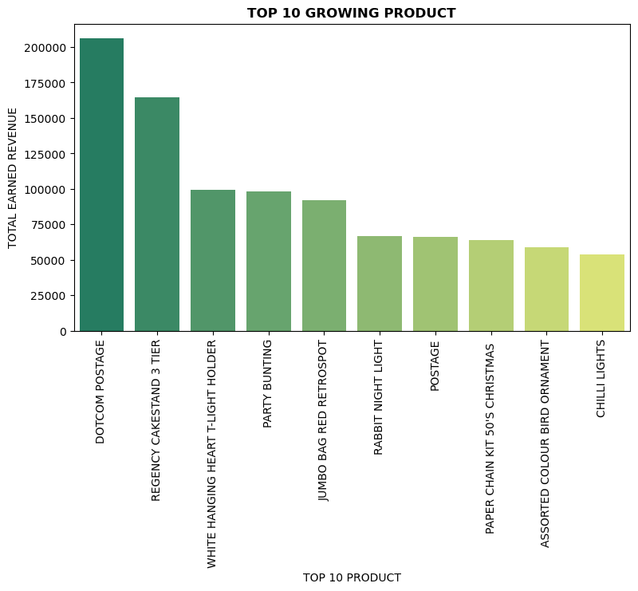

```python
top_10 = product_sale.nlargest(10, 'revenue')
display(top_10)
plt.figure(figsize = (9,5))
sns.barplot(data = top_10,x = 'Description',y = 'revenue',palette = 'summer')
plt.xlabel('TOP 10 PRODUCT')
plt.ylabel('TOTAL EARNED REVENUE')
plt.xticks(rotation=90)
plt.title('TOP 10 GROWING PRODUCT',fontweight = 'bold')
plt.show()
```

#### NOW WE'LL CHECK LOWEST 10 PRODUCT APART FROM WHICH REVENUES

|  | index | Description | revenue |
| --- | --- | --- | --- |
| 0 | 171 | AMAZON FEE | -221520.500 |
| 1 | 2246 | Manual | -69031.640 |
| 2 | 281 | Adjust bad debt | -11062.060 |
| 3 | 934 | CRUK Commission | -7933.430 |
| 4 | 615 | Bank Charges | -7175.639 |
| 5 | 1126 | Discount | -5696.220 |
| 6 | 3059 | SAMPLES | -3039.650 |
| 7 | 3903 | WHITE CHERRY LIGHTS | -54.000 |
| 8 | 922 | CREAM SWEETHEART MAGAZINE RACK | -46.850 |
| 9 | 3977 | WOODEN BOX ADVENT CALENDAR | -45.700 |

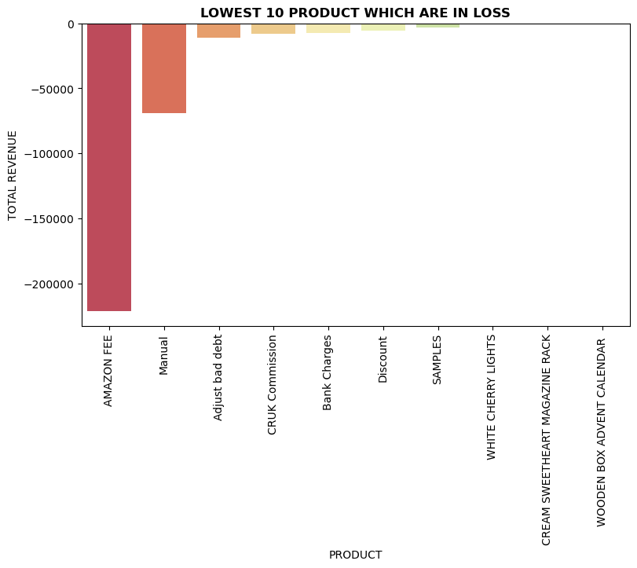

```python
lowest_10 = product_sale.nsmallest(10,'revenue').reset_index()
display(lowest_10)
plt.figure(figsize = (9,5))
sns.barplot(data = lowest_10,x = lowest_10['Description'], y = 'revenue', palette = 'Spectral')
plt.xticks(rotation = 90)
plt.xlabel('PRODUCT')
plt.ylabel('TOTAL REVENUE')
plt.title('LOWEST 10 PRODUCT WHICH ARE IN LOSS' , fontweight= 'bold')
plt.show()
```

#### ------------------------->>> Geographic Insights: Showcase regions where revenue is particularly strong. <<<---------------------------

```python
region_group = data.groupby('Country').sum()['revenue'].reset_index()
region_group.sort_values(by = 'revenue', ascending = False,ignore_index = True,inplace = True)
region_group
```

|  | Country | revenue |
| --- | --- | --- |
| 0 | United Kingdom | 8166891.414 |
| 1 | Netherlands | 284661.540 |
| 2 | EIRE | 262993.380 |
| 3 | Germany | 221509.470 |
| 4 | France | 197317.110 |
| 5 | Australia | 137009.770 |
| 6 | Switzerland | 56363.050 |
| 7 | Spain | 54756.030 |
| 8 | Belgium | 40910.960 |
| 9 | Sweden | 36585.410 |
| 10 | Japan | 35340.620 |
| 11 | Norway | 35163.460 |
| 12 | Portugal | 29302.970 |
| 13 | Finland | 22326.740 |
| 14 | Channel Islands | 20076.390 |
| 15 | Denmark | 18768.140 |
| 16 | Italy | 16890.510 |
| 17 | Cyprus | 12850.360 |
| 18 | Austria | 10154.320 |
| 19 | Hong Kong | 9908.240 |
| 20 | Singapore | 9120.390 |
| 21 | Israel | 7891.970 |
| 22 | Poland | 7213.140 |
| 23 | Unspecified | 4740.940 |
| 24 | Greece | 4710.520 |
| 25 | Iceland | 4310.000 |
| 26 | Canada | 3666.380 |
| 27 | Malta | 2505.470 |
| 28 | United Arab Emirates | 1902.280 |
| 29 | USA | 1730.920 |
| 30 | Lebanon | 1693.880 |
| 31 | Lithuania | 1661.060 |
| 32 | European Community | 1291.750 |
| 33 | Brazil | 1143.600 |
| 34 | RSA | 1002.310 |
| 35 | Czech Republic | 707.720 |
| 36 | Bahrain | 548.400 |
| 37 | Saudi Arabia | 131.170 |

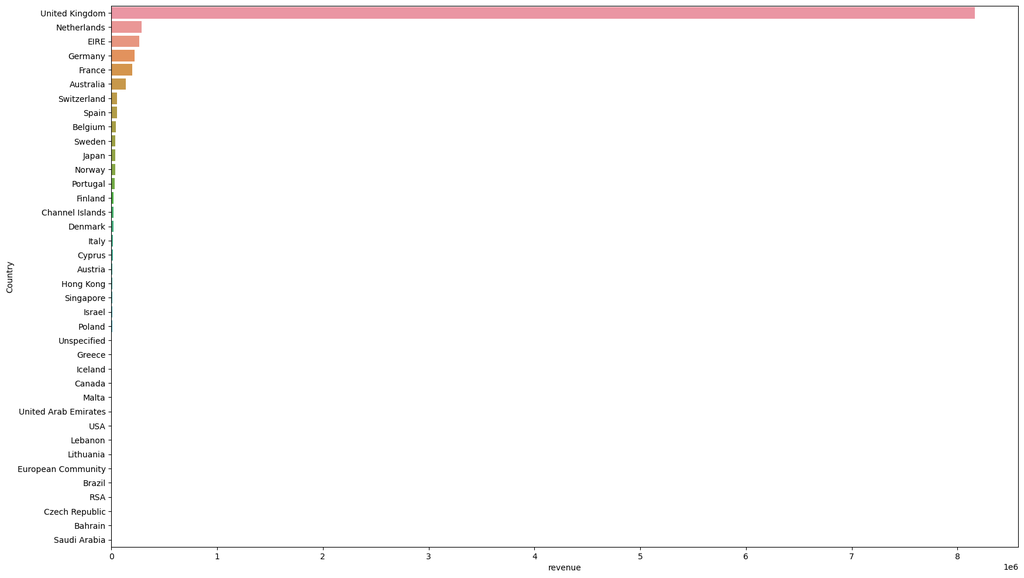

```python
plt.figure(figsize =(20,12))
sns.barplot(data = region_group, y = 'Country', x = 'revenue')
```

#### Best Year For Sale

|  | Year | revenue |
| --- | --- | --- |
| 0 | 2010 | 746659.940 |
| 1 | 2011 | 8979091.844 |

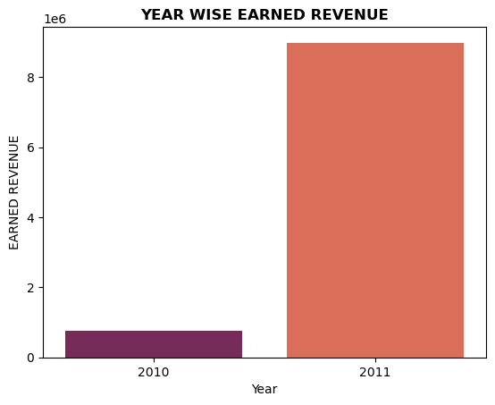

```python
year_group = data.groupby('Year').sum()['revenue'].reset_index()
display(year_group)
sns.barplot(data = year_group, x = year_group['Year'],y = year_group['revenue'], palette = 'rocket')
plt.xlabel('Year')
plt.ylabel('EARNED REVENUE')
plt.title('YEAR WISE EARNED REVENUE',fontweight = 'bold')
plt.show()
```

#### Best Day & Best Time For Sale

```python
def check(groupby , permeter,header,choose_color):
    temp = data.groupby(groupby).sum()[permeter].reset_index()
    display(temp)
    sns.barplot(data = temp , x = groupby, y = permeter,palette = choose_color)
    plt.xlabel('NAME OF DAY')
    plt.ylabel("EARNED REVENUE")
    plt.title(f" BEST {header} FOR EARNED REVENUE",fontweight = 'bold' )
    plt.xticks(rotation = 75)
    plt.figure(figsize= (9,5))
    plt.show()
    return ""
```

|  | Month | revenue |
| --- | --- | --- |
| 0 | April | 658822.121 |
| 1 | August | 757923.200 |
| 2 | December | 528337.920 |
| 3 | February | 587104.620 |
| 4 | January | 664481.080 |
| 5 | July | 887404.191 |
| 6 | June | 797475.370 |
| 7 | March | 756089.290 |
| 8 | May | 762946.280 |
| 9 | November | 1295671.270 |
| 10 | October | 986240.770 |
| 11 | September | 1043255.672 |

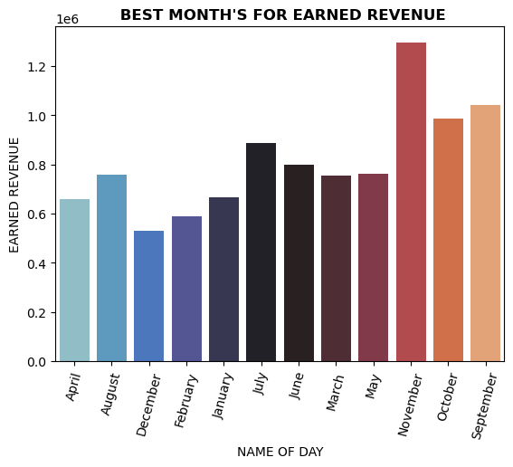

```
''
```

```python
display(check('Month','revenue',"MONTH'S" ,'icefire'))
```

|  | Day_Name | revenue |
| --- | --- | --- |
| 0 | Friday | 1482770.141 |
| 1 | Monday | 1484777.691 |
| 2 | Saturday | 543534.790 |
| 3 | Sunday | 1048394.261 |
| 4 | Thursday | 1770449.150 |
| 5 | Tuesday | 1980703.351 |
| 6 | Wednesday | 1415122.400 |

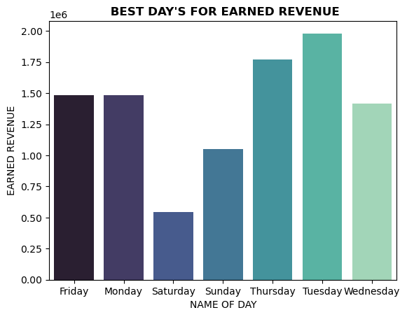

```
''
```

```python
display(check('Day_Name','revenue',"DAY'S",'mako'))
```

|  | Hour | revenue |
| --- | --- | --- |
| 0 | 6 | -497.350 |
| 1 | 7 | 31009.320 |
| 2 | 8 | 281713.020 |
| 3 | 9 | 766524.171 |
| 4 | 10 | 1327317.731 |
| 5 | 11 | 1146426.530 |
| 6 | 12 | 1357568.320 |
| 7 | 13 | 1172966.670 |
| 8 | 14 | 1091373.191 |
| 9 | 15 | 1186781.100 |
| 10 | 16 | 727621.110 |
| 11 | 17 | 434806.191 |
| 12 | 18 | 140359.260 |
| 13 | 19 | 45862.430 |
| 14 | 20 | 15920.090 |

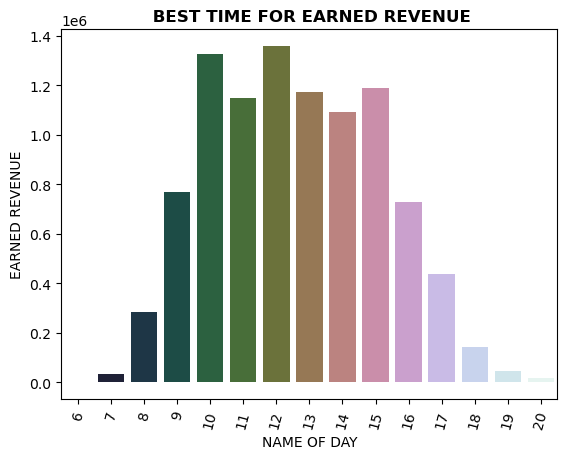

```
''
```

```python
check('Hour','revenue','TIME','cubehelix')
```

#### BEST SELLING MONTH OF TOP GROWING COMPANY

```python
grouped_data = data.groupby(['Country','Month']).sum()['revenue'].reset_index()
grouped_data = grouped_data[(grouped_data['Country']!='Unspecified')]
grouped_data
```

|  | Country | Month | revenue |
| --- | --- | --- | --- |
| 0 | Australia | April | -99.490 |
| 1 | Australia | August | 22560.940 |
| 2 | Australia | December | 1404.370 |
| 3 | Australia | February | 14862.710 |
| 4 | Australia | January | 4969.200 |
| ... | ... | ... | ... |
| 288 | United Kingdom | March | 642619.740 |
| 289 | United Kingdom | May | 624161.610 |
| 290 | United Kingdom | November | 1113228.800 |
| 291 | United Kingdom | October | 805432.460 |
| 292 | United Kingdom | September | 884916.522 |

293 rows × 3 columns

#### As From Our Previous Analysis We Know That Top Growing Company From (region_group) Data

```python
cntry = region_group.Country[0:10]
list(cntry)
```

```
['United Kingdom',
 'Netherlands',
 'EIRE',
 'Germany',
 'France',
 'Australia',
 'Switzerland',
 'Spain',
 'Belgium',
 'Sweden']
```

```
--------------------------------->>>> UNITED KINGDOM AND THEIR REVENUE <<<<---------------------------------
```

|  | Month | revenue |
| --- | --- | --- |
| 281 | April | 599176.341 |
| 282 | August | 639829.640 |
| 283 | December | 443566.920 |
| 284 | February | 496181.030 |
| 285 | January | 521079.670 |
| 286 | July | 743826.581 |
| 287 | June | 652872.100 |
| 288 | March | 642619.740 |
| 289 | May | 624161.610 |
| 290 | November | 1113228.800 |
| 291 | October | 805432.460 |
| 292 | September | 884916.522 |

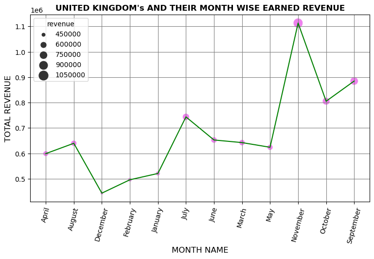

```
--------------------------------->>>> NETHERLANDS AND THEIR REVENUE <<<<---------------------------------
```

|  | Month | revenue |
| --- | --- | --- |
| 184 | April | 692.36 |
| 185 | August | 10639.40 |
| 186 | December | 25895.94 |
| 187 | February | 25978.09 |
| 188 | January | 32441.01 |
| 189 | July | 11675.37 |
| 190 | June | 21773.04 |
| 191 | March | 22356.69 |
| 192 | May | 14259.07 |
| 193 | November | 31521.04 |
| 194 | October | 49426.44 |
| 195 | September | 38003.09 |

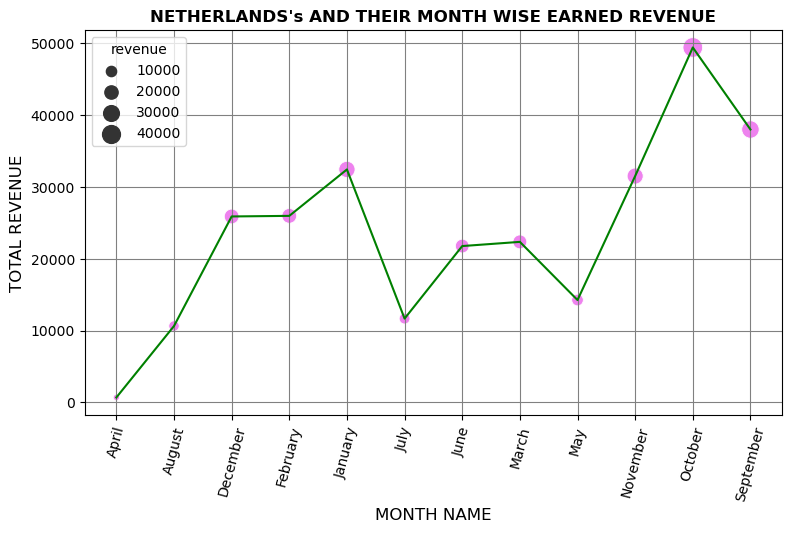

```
--------------------------------->>>> EIRE AND THEIR REVENUE <<<<---------------------------------
```

|  | Month | revenue |
| --- | --- | --- |
| 74 | April | 7513.49 |
| 75 | August | 13928.25 |
| 76 | December | 6172.01 |
| 77 | February | 8569.04 |
| 78 | January | 35683.04 |
| 79 | July | 49678.19 |
| 80 | June | 26171.01 |
| 81 | March | 13423.69 |
| 82 | May | 21532.31 |
| 83 | November | 29796.42 |
| 84 | October | 28232.05 |
| 85 | September | 22293.88 |

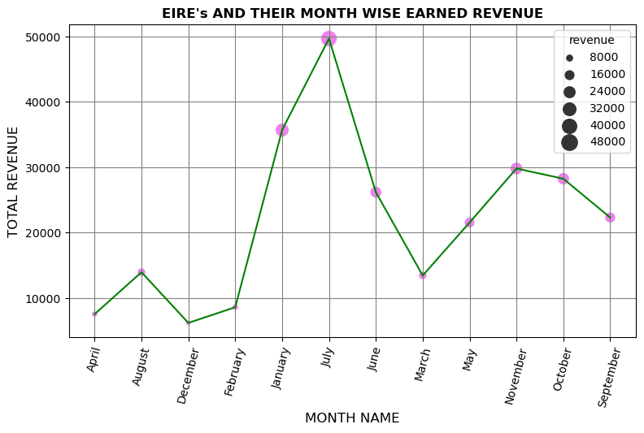

```
--------------------------------->>>> GERMANY AND THEIR REVENUE <<<<---------------------------------
```

|  | Month | revenue |
| --- | --- | --- |
| 115 | April | 15523.20 |
| 116 | August | 20122.26 |
| 117 | December | 21483.92 |
| 118 | February | 8366.98 |
| 119 | January | 16543.60 |
| 120 | July | 25158.48 |
| 121 | June | 14237.32 |
| 122 | March | 14024.24 |
| 123 | May | 18223.84 |
| 124 | November | 29787.21 |
| 125 | October | 22521.90 |
| 126 | September | 15516.52 |

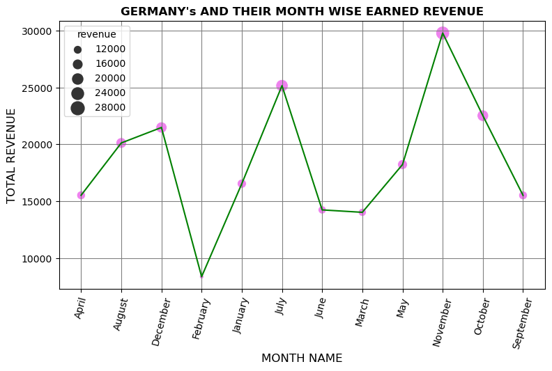

```
--------------------------------->>>> FRANCE AND THEIR REVENUE <<<<---------------------------------
```

|  | Month | revenue |
| --- | --- | --- |
| 103 | April | 8673.15 |
| 104 | August | 17408.42 |
| 105 | December | 7277.90 |
| 106 | February | 8745.25 |
| 107 | January | 16162.13 |
| 108 | July | 12064.80 |
| 109 | June | 12717.63 |
| 110 | March | 17758.86 |
| 111 | May | 21854.72 |
| 112 | November | 31545.67 |
| 113 | October | 21799.09 |
| 114 | September | 21309.49 |

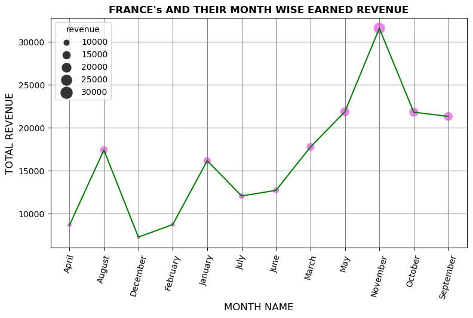

```
--------------------------------->>>> AUSTRALIA AND THEIR REVENUE <<<<---------------------------------
```

|  | Month | revenue |
| --- | --- | --- |
| 0 | April | -99.49 |
| 1 | August | 22560.94 |
| 2 | December | 1404.37 |
| 3 | February | 14862.71 |
| 4 | January | 4969.20 |
| 5 | July | 4959.57 |
| 6 | June | 33020.91 |
| 7 | March | 17219.63 |
| 8 | May | 29772.82 |
| 9 | November | 6104.30 |
| 10 | October | 81.60 |
| 11 | September | 2153.21 |

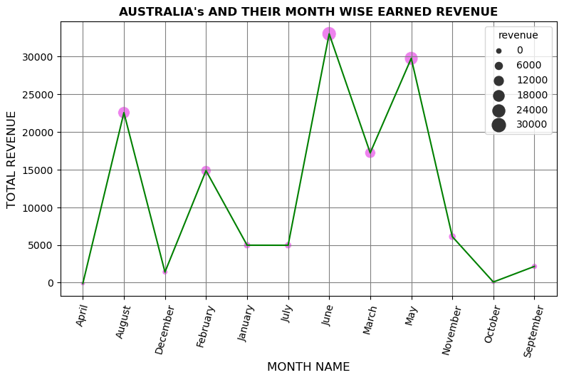

```
--------------------------------->>>> SWITZERLAND AND THEIR REVENUE <<<<---------------------------------
```

|  | Month | revenue |
| --- | --- | --- |
| 260 | April | 2545.37 |
| 261 | August | 1876.04 |
| 262 | December | 1663.44 |
| 263 | February | 5931.21 |
| 264 | January | 4592.03 |
| 265 | July | 2781.08 |
| 266 | June | 7470.11 |
| 267 | March | 1658.20 |
| 268 | May | 5834.27 |
| 269 | November | 3395.15 |
| 270 | October | 9806.61 |
| 271 | September | 8809.54 |

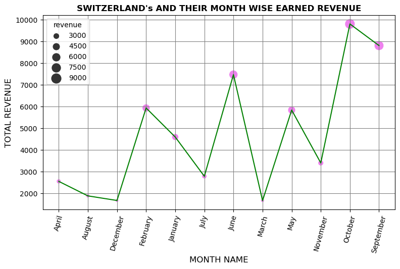

```
--------------------------------->>>> SPAIN AND THEIR REVENUE <<<<---------------------------------
```

|  | Month | revenue |
| --- | --- | --- |
| 236 | April | 9090.05 |
| 237 | August | 3492.18 |
| 238 | December | 1049.01 |
| 239 | February | 425.36 |
| 240 | January | 1174.70 |
| 241 | July | 4524.68 |
| 242 | June | 1954.54 |
| 243 | March | 6755.75 |
| 244 | May | 2447.24 |
| 245 | November | 11187.99 |
| 246 | October | 7193.64 |
| 247 | September | 5460.89 |

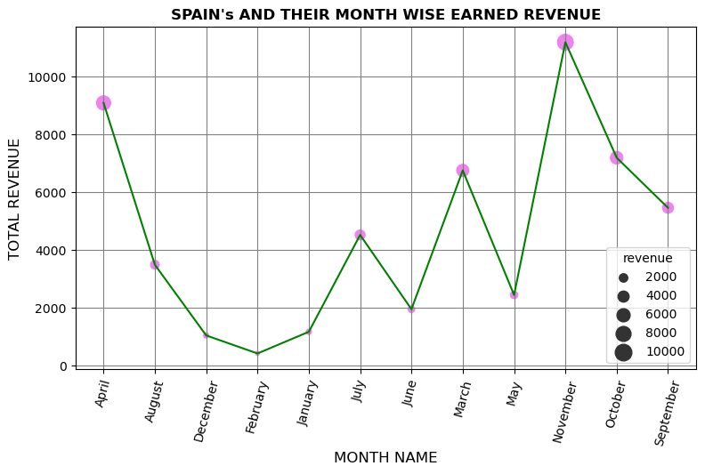

```
--------------------------------->>>> BELGIUM AND THEIR REVENUE <<<<---------------------------------
```

|  | Month | revenue |
| --- | --- | --- |
| 26 | April | 3282.33 |
| 27 | August | 2314.89 |
| 28 | December | 2850.98 |
| 29 | February | 3343.66 |
| 30 | January | 1181.83 |
| 31 | July | 3342.49 |
| 32 | June | 4022.01 |
| 33 | March | 3352.86 |
| 34 | May | 2976.37 |
| 35 | November | 4386.84 |
| 36 | October | 5867.94 |
| 37 | September | 3988.76 |

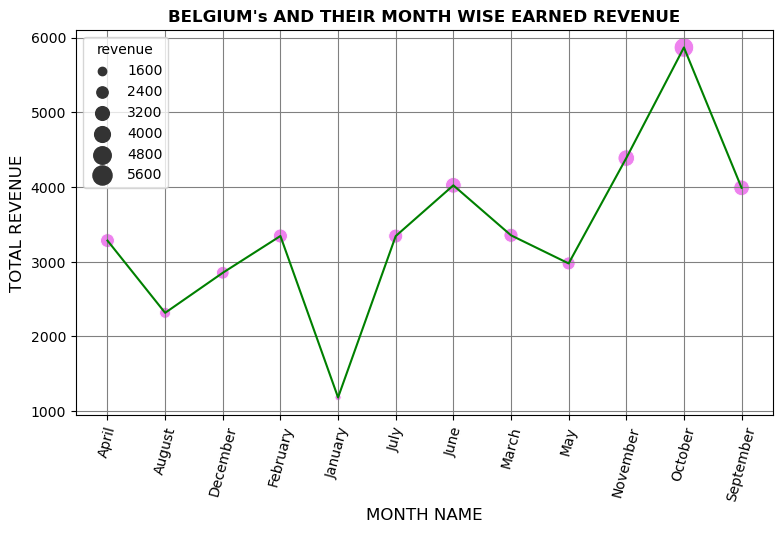

```
--------------------------------->>>> SWEDEN AND THEIR REVENUE <<<<---------------------------------
```

|  | Month | revenue |
| --- | --- | --- |
| 248 | April | 1920.16 |
| 249 | August | 747.61 |
| 250 | December | 5204.18 |
| 251 | February | 431.00 |
| 252 | January | 3448.26 |
| 253 | July | 3976.99 |
| 254 | June | 3887.29 |
| 255 | March | 4589.68 |
| 256 | May | 115.60 |
| 257 | November | 1970.37 |
| 258 | October | 5708.56 |
| 259 | September | 4585.71 |

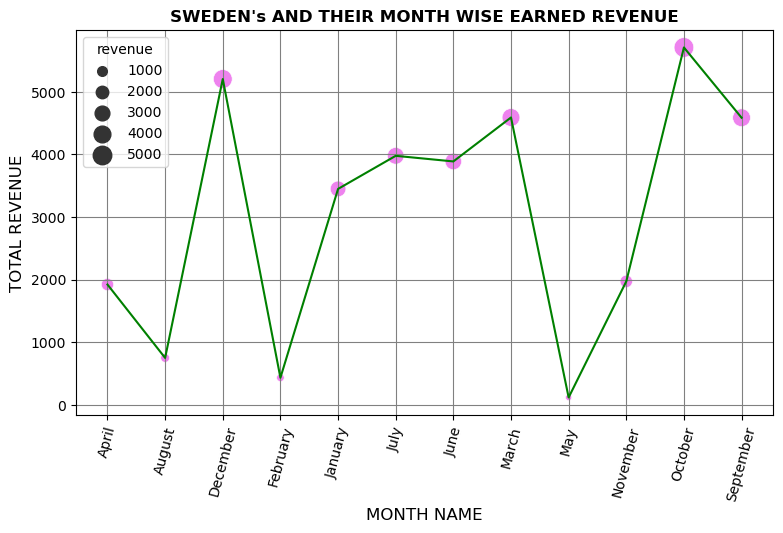

```python
for i in range(len(cntry)):
    temp = grouped_data[(grouped_data['Country']==cntry[i])]
    print(f"--------------------------------->>>> {cntry[i].upper()} AND THEIR REVENUE <<<<--------------------------------- ")
    display(temp[['Month','revenue']])
    plt.figure(figsize = (9,5))
    plt.grid(True, color='grey')
    sns.lineplot(data = temp,x = 'Month',y = 'revenue', color = 'g', )
    sns.scatterplot(data = temp, x = 'Month', y = 'revenue', size  = 'revenue',sizes = (20,200), color = 'violet')
    plt.xlabel('MONTH NAME',fontsize = 12)
    plt.ylabel('TOTAL REVENUE',fontsize = 12)
    plt.xticks(rotation = 75)
    plt.title(f"""{cntry[i].upper()+"'s"} AND THEIR MONTH WISE EARNED REVENUE""",fontweight='bold')
    plt.show()
```

#### NOW WE'LL ANALYSIS LESS SUCESSFUL REGION MONTH WISE

```python
cont = region_group.Country[-1:27:-1]
cont = list(cont)
cont
```

```
['Saudi Arabia',
 'Bahrain',
 'Czech Republic',
 'RSA',
 'Brazil',
 'European Community',
 'Lithuania',
 'Lebanon',
 'USA',
 'United Arab Emirates']
```

```python
for i in range(len(cont)):
    temp = grouped_data[(grouped_data['Country']==cont[i])]
    temp = temp.sort_values(by='revenue',ascending = False)
    print(f"--------------------------------->>>> {cont[i].upper()} AND THEIR REVENUE <<<<--------------------------------- ")
    display(temp[['Month','revenue']])
```

```
--------------------------------->>>> SAUDI ARABIA AND THEIR REVENUE <<<<---------------------------------
```

|  | Month | revenue |
| --- | --- | --- |
| 229 | February | 145.92 |
| 230 | March | -14.75 |

```
--------------------------------->>>> BAHRAIN AND THEIR REVENUE <<<<---------------------------------
```

|  | Month | revenue |
| --- | --- | --- |
| 25 | September | 459.40 |
| 23 | December | 205.74 |
| 24 | May | -116.74 |

```
--------------------------------->>>> CZECH REPUBLIC AND THEIR REVENUE <<<<---------------------------------
```

|  | Month | revenue |
| --- | --- | --- |
| 62 | February | 549.26 |
| 64 | July | 277.48 |
| 63 | January | -57.51 |
| 65 | November | -61.51 |

```
--------------------------------->>>> RSA AND THEIR REVENUE <<<<---------------------------------
```

|  | Month | revenue |
| --- | --- | --- |
| 228 | October | 1002.31 |

```
--------------------------------->>>> BRAZIL AND THEIR REVENUE <<<<---------------------------------
```

|  | Month | revenue |
| --- | --- | --- |
| 38 | April | 1143.6 |

```
--------------------------------->>>> EUROPEAN COMMUNITY AND THEIR REVENUE <<<<---------------------------------
```

|  | Month | revenue |
| --- | --- | --- |
| 87 | July | 676.80 |
| 89 | May | 387.05 |
| 86 | April | 191.40 |
| 88 | June | 45.00 |
| 90 | October | -8.50 |

```
--------------------------------->>>> LITHUANIA AND THEIR REVENUE <<<<---------------------------------
```

|  | Month | revenue |
| --- | --- | --- |
| 179 | May | 1598.06 |
| 178 | August | 63.00 |

```
--------------------------------->>>> LEBANON AND THEIR REVENUE <<<<---------------------------------
```

|  | Month | revenue |
| --- | --- | --- |
| 177 | January | 1693.88 |

```
--------------------------------->>>> USA AND THEIR REVENUE <<<<---------------------------------
```

|  | Month | revenue |
| --- | --- | --- |
| 277 | October | 2311.20 |
| 276 | May | 615.28 |
| 272 | April | 383.95 |
| 275 | February | 269.96 |
| 273 | August | -269.96 |
| 274 | December | -1579.51 |

```
--------------------------------->>>> UNITED ARAB EMIRATES AND THEIR REVENUE <<<<---------------------------------
```

|  | Month | revenue |
| --- | --- | --- |
| 279 | January | 975.54 |
| 278 | February | 889.24 |
| 280 | September | 37.50 |

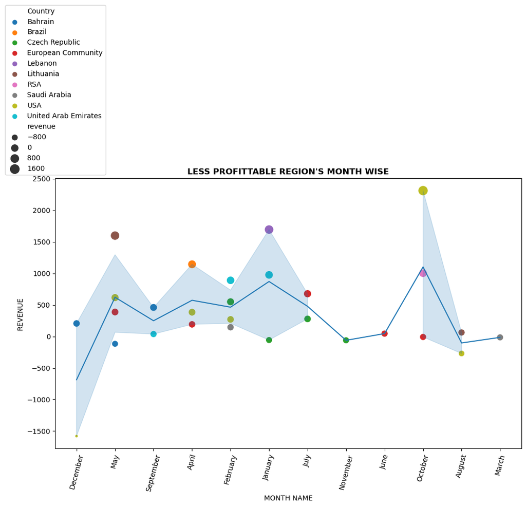

```python
test = grouped_data[(grouped_data['Country'].isin(cont))]
plt.figure(figsize = (12,7))
sns.scatterplot(data = test, x = 'Month', y = 'revenue', hue = 'Country', size = 'revenue', sizes = (20,200),s = 5)
sns.lineplot(data = test , x = 'Month', y = 'revenue')
plt.legend(loc='lower center', bbox_to_anchor=(0.0, 1))
plt.xticks(rotation = 75)
plt.xlabel('MONTH NAME')
plt.ylabel('REVENUE')
plt.title("LESS PROFITTABLE REGION'S MONTH WISE",fontweight = 'bold')
plt.show()
```

#### Top Growing Country Coustomer Wise in Each Month

```python
print("------------------->>> TOP 10 GROWING COUNTRY COUSTOMER WISE <<<------------------")
check = data.groupby('Country').count()['InvoiceNo'].reset_index()
check = check.sort_values(by = 'InvoiceNo' , ascending = False)
check = check.nlargest(10,'InvoiceNo')
display(check)
```

```
------------------->>> TOP 10 GROWING COUNTRY COUSTOMER WISE <<<------------------
```

|  | Country | InvoiceNo |
| --- | --- | --- |
| 36 | United Kingdom | 490232 |
| 14 | Germany | 9480 |
| 13 | France | 8541 |
| 10 | EIRE | 8184 |
| 31 | Spain | 2528 |
| 24 | Netherlands | 2371 |
| 3 | Belgium | 2069 |
| 33 | Switzerland | 1994 |
| 27 | Portugal | 1510 |
| 0 | Australia | 1258 |

#### Now We'll Check Growing Country Coustomer Wise in Each Month

```python
cont_name = check['Country']
cont_name = list(cont_name)
cont_name
```

```
['United Kingdom',
 'Germany',
 'France',
 'EIRE',
 'Spain',
 'Netherlands',
 'Belgium',
 'Switzerland',
 'Portugal',
 'Australia']
```

```python
data_grouped_2 = data.groupby(['Country','Month']).count()['InvoiceNo'].reset_index()
data_grouped_2.sort_values(by= 'InvoiceNo',ascending = False)
color = ["dark:salmon_r","YlOrBr","Blues","YlOrBr","icefire","Spectral","coolwarm","Spectral","rocket","cubehelix"]
```

```
------------------>>>> NUMBER OF COUSTOMER BY EACH MONTH IN UNITED KINGDOM <<<<------------------
```

|  | Month | InvoiceNo |
| --- | --- | --- |
| 281 | April | 34319 |
| 282 | August | 40319 |
| 283 | December | 27214 |
| 284 | February | 30826 |
| 285 | January | 35890 |
| 286 | July | 42140 |
| 287 | June | 41687 |
| 288 | March | 35269 |
| 289 | May | 38242 |
| 290 | November | 66606 |
| 291 | October | 51269 |
| 292 | September | 46451 |

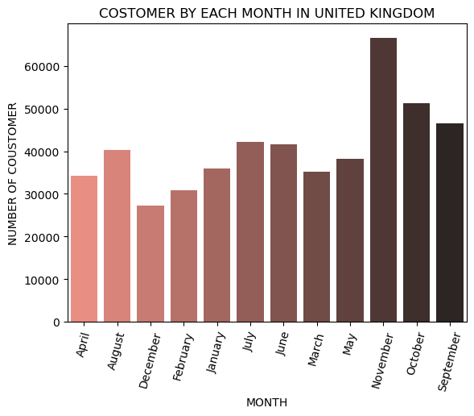

```
------------------>>>> NUMBER OF COUSTOMER BY EACH MONTH IN GERMANY <<<<------------------
```

|  | Month | InvoiceNo |
| --- | --- | --- |
| 115 | April | 653 |
| 116 | August | 880 |
| 117 | December | 546 |
| 118 | February | 478 |
| 119 | January | 785 |
| 120 | July | 1149 |
| 121 | June | 669 |
| 122 | March | 554 |
| 123 | May | 847 |
| 124 | November | 1308 |
| 125 | October | 970 |
| 126 | September | 641 |

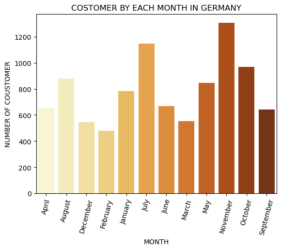

```
------------------>>>> NUMBER OF COUSTOMER BY EACH MONTH IN FRANCE <<<<------------------
```

|  | Month | InvoiceNo |
| --- | --- | --- |
| 103 | April | 522 |
| 104 | August | 856 |
| 105 | December | 391 |
| 106 | February | 432 |
| 107 | January | 604 |
| 108 | July | 515 |
| 109 | June | 566 |
| 110 | March | 689 |
| 111 | May | 938 |
| 112 | November | 1459 |
| 113 | October | 585 |
| 114 | September | 984 |

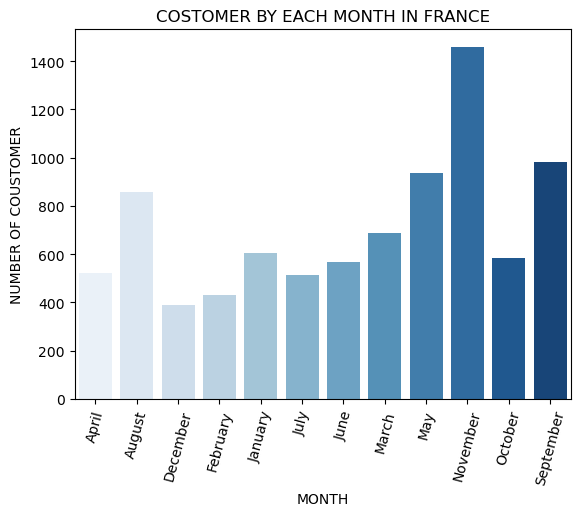

```
------------------>>>> NUMBER OF COUSTOMER BY EACH MONTH IN EIRE <<<<------------------
```

|  | Month | InvoiceNo |
| --- | --- | --- |
| 74 | April | 324 |
| 75 | August | 670 |
| 76 | December | 401 |
| 77 | February | 368 |
| 78 | January | 521 |
| 79 | July | 1083 |
| 80 | June | 750 |
| 81 | March | 610 |
| 82 | May | 680 |
| 83 | November | 1073 |
| 84 | October | 841 |
| 85 | September | 863 |

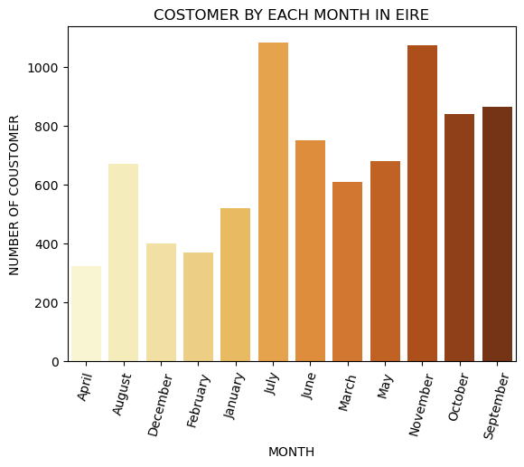

```
------------------>>>> NUMBER OF COUSTOMER BY EACH MONTH IN SPAIN <<<<------------------
```

|  | Month | InvoiceNo |
| --- | --- | --- |
| 236 | April | 259 |
| 237 | August | 263 |
| 238 | December | 30 |
| 239 | February | 17 |
| 240 | January | 170 |
| 241 | July | 277 |
| 242 | June | 162 |
| 243 | March | 247 |
| 244 | May | 88 |
| 245 | November | 267 |
| 246 | October | 438 |
| 247 | September | 310 |

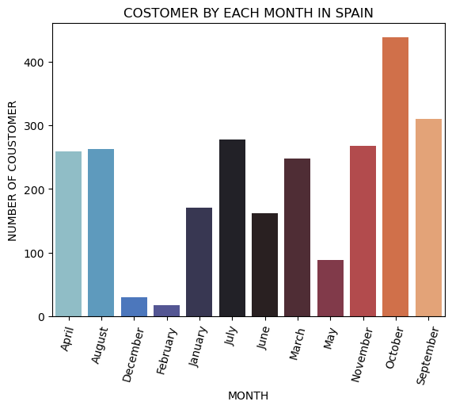

```
------------------>>>> NUMBER OF COUSTOMER BY EACH MONTH IN NETHERLANDS <<<<------------------
```

|  | Month | InvoiceNo |
| --- | --- | --- |
| 184 | April | 9 |
| 185 | August | 120 |
| 186 | December | 185 |
| 187 | February | 233 |
| 188 | January | 269 |
| 189 | July | 106 |
| 190 | June | 301 |
| 191 | March | 178 |
| 192 | May | 117 |
| 193 | November | 219 |
| 194 | October | 305 |
| 195 | September | 329 |

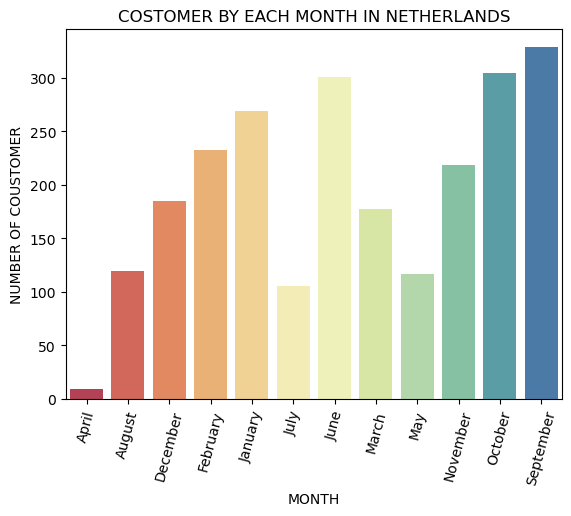

```
------------------>>>> NUMBER OF COUSTOMER BY EACH MONTH IN BELGIUM <<<<------------------
```

|  | Month | InvoiceNo |
| --- | --- | --- |
| 26 | April | 162 |
| 27 | August | 129 |
| 28 | December | 160 |
| 29 | February | 183 |
| 30 | January | 59 |
| 31 | July | 179 |
| 32 | June | 216 |
| 33 | March | 153 |
| 34 | May | 165 |
| 35 | November | 183 |
| 36 | October | 286 |
| 37 | September | 194 |

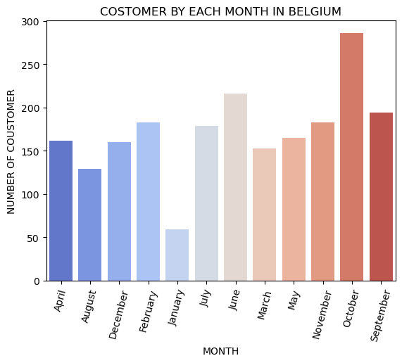

```
------------------>>>> NUMBER OF COUSTOMER BY EACH MONTH IN SWITZERLAND <<<<------------------
```

|  | Month | InvoiceNo |
| --- | --- | --- |
| 260 | April | 108 |
| 261 | August | 89 |
| 262 | December | 65 |
| 263 | February | 298 |
| 264 | January | 173 |
| 265 | July | 130 |
| 266 | June | 181 |
| 267 | March | 66 |
| 268 | May | 236 |
| 269 | November | 160 |
| 270 | October | 271 |
| 271 | September | 217 |

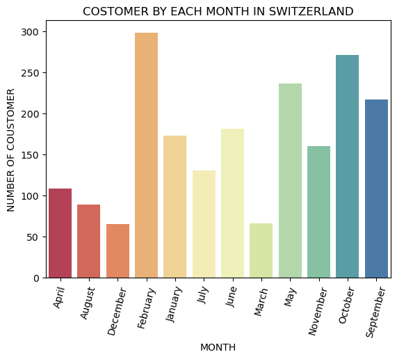

```
------------------>>>> NUMBER OF COUSTOMER BY EACH MONTH IN PORTUGAL <<<<------------------
```

|  | Month | InvoiceNo |
| --- | --- | --- |
| 216 | April | 56 |
| 217 | August | 180 |
| 218 | December | 104 |
| 219 | February | 125 |
| 220 | January | 66 |
| 221 | July | 134 |
| 222 | June | 271 |
| 223 | March | 78 |
| 224 | May | 25 |
| 225 | November | 173 |
| 226 | October | 179 |
| 227 | September | 119 |

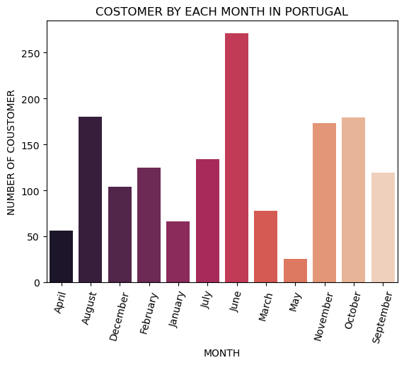

```
------------------>>>> NUMBER OF COUSTOMER BY EACH MONTH IN AUSTRALIA <<<<------------------
```

|  | Month | InvoiceNo |
| --- | --- | --- |
| 0 | April | 5 |
| 1 | August | 122 |
| 2 | December | 45 |
| 3 | February | 83 |
| 4 | January | 83 |
| 5 | July | 229 |
| 6 | June | 249 |
| 7 | March | 105 |
| 8 | May | 185 |
| 9 | November | 54 |
| 10 | October | 1 |
| 11 | September | 97 |

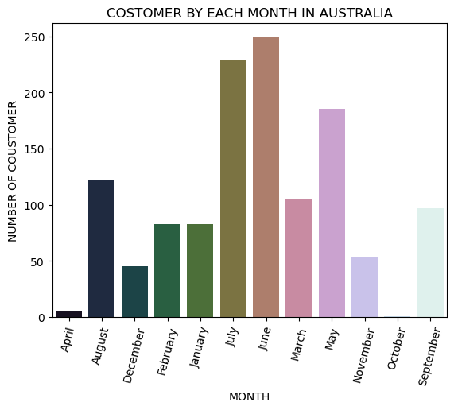

```python
for i in range(len(cont_name)):
    temp = data_grouped_2[(data_grouped_2['Country']==cont_name[i])]
    print(f"------------------>>>> NUMBER OF COUSTOMER BY EACH MONTH IN {cont_name[i].upper()} <<<<------------------")
    display(temp[['Month','InvoiceNo']])
    sns.barplot(data = temp , x = 'Month', y = 'InvoiceNo', palette = color[i])
    plt.xlabel('MONTH')
    plt.ylabel('NUMBER OF COUSTOMER')
    plt.xticks(rotation = 75)
    plt.title(f'COSTOMER BY EACH MONTH IN {cont_name[i].upper()}')
    plt.show()
```